# Algoritma Fuzzy C-Means

Ahmad Khoirul Anam-Institut Teknologi Statistika dan Bisnis Muhammadiyah

2023-01-12

# Algoritma

Fuzzy C-Means (FCM) merupakan cara kerjanya menggunakan medote Hard K-Means.

Fuzzy C-Means (FCM) juga mengunakan metode pengelompokan data.

Cluster terbentuk derajat atau tingkat anggotanya yang berbeda antara 0 hingga 1

# Tahapan Algoritma

1. Input Data terlebih dahulu.
2. Inisialisasi menentukan : -Jumlah Cluster(c), -Error terkecil yang diharapkan, -Bobot pangkat (w), -Iterasi awal.
3. Inisiasikan matriks Pseudo-Partition -> Memberikan nirai random pada matriks Fuzzy Pseudo partition dengan syarat antara u (u1), i (u2), dan u (u3) berjumlah satu, ∑uji = 1.
4. Pengulangan -> Langkah-langkah : u1*(a1), u1*(a2), u1*(a3), u1*(a4), u1*(a5) u2*(a1), u2*(a2), u2*(a3), u2*(a4), u2*(a5). Jika perubahan pada nilai fungsi objektif masih di atas nilai error terkecil, maka pengulangan langkah ini masih berlanjut.
5. Hitunglah nilai centroid dari masih – masih Cluster.
6. Hitunglah Kembali matriks Fuzzy pseudo – partition matriks partisi.

# 1. Analisis Kluster Pemartisian Menggunakan Fuzzy C-Means

Fuzzy C-Means (FCM) adalah algoritma soft custering yang diusulkan oleh Bezdek (1974; 1981). Tidak seperti algoritma K-means di mana setiap objek data adalah anggota dari hanya satu cluster, objek data adalah anggota dari semua cluster dengan berbagai tingkat anggota fuzzy antara 0 dan 1 di FCM. Oleh karena itu, objek data yang lebih dekat ke pusat cluster memiliki tingkat keanggotaan yang lebih tinggi daripada objek yang tersebar di perbatasan cluster.

## 1.1 Menampilkan atau menjalankan perintah ‘ppclust’ analisi C-Means

```r
library(ppclust)
library (readr)
```

## 1.2 Memanggil data yang dibutuhkan

Memanggil hasil pengelompokan, dalam kelompok ini menggunakan fungsi dari fungsi analisis kluster seperti ‘cluster’, ‘fclust’ dan ‘factoextra’.Maka dapat dilihat sebagai berikut:

```r
library(factoextra)
```

```r
library(cluster)
library(fclust)
library(ggplot2)
library (readr)
```

# 2. Menjalankan dataset

```r
data("swiss")
data=swiss[, -5]
data
```

|  | Fertility | Agriculture | Examination | Education | Infant.Mortality |
| --- | --- | --- | --- | --- | --- |
| Courtelary | 80.2 | 17.0 | 15 | 12 | 22.2 |
| Delemont | 83.1 | 45.1 | 6 | 9 | 22.2 |
| Franches-Mnt | 92.5 | 39.7 | 5 | 5 | 20.2 |
| Moutier | 85.8 | 36.5 | 12 | 7 | 20.3 |
| Neuveville | 76.9 | 43.5 | 17 | 15 | 20.6 |
| Porrentruy | 76.1 | 35.3 | 9 | 7 | 26.6 |
| Broye | 83.8 | 70.2 | 16 | 7 | 23.6 |
| Glane | 92.4 | 67.8 | 14 | 8 | 24.9 |
| Gruyere | 82.4 | 53.3 | 12 | 7 | 21.0 |
| Sarine | 82.9 | 45.2 | 16 | 13 | 24.4 |

[output cut: 37 more lines]

## 2.1 Mau menampilkan 6 data diawal pada data Kabupaten

```r
head(data)
```

|  | Fertility | Agriculture | Examination | Education | Infant.Mortality |
| --- | --- | --- | --- | --- | --- |
| Courtelary | 80.2 | 17.0 | 15 | 12 | 22.2 |
| Delemont | 83.1 | 45.1 | 6 | 9 | 22.2 |
| Franches-Mnt | 92.5 | 39.7 | 5 | 5 | 20.2 |
| Moutier | 85.8 | 36.5 | 12 | 7 | 20.3 |
| Neuveville | 76.9 | 43.5 | 17 | 15 | 20.6 |
| Porrentruy | 76.1 | 35.3 | 9 | 7 | 26.6 |

## 2.2 Mau menampilkan 6 data diakhir pada data Kabupaten

```r
tail(data)
```

|  | Fertility | Agriculture | Examination | Education | Infant.Mortality |
| --- | --- | --- | --- | --- | --- |
| Neuchatel | 64.4 | 17.6 | 35 | 32 | 23.0 |
| Val de Ruz | 77.6 | 37.6 | 15 | 7 | 20.0 |
| ValdeTravers | 67.6 | 18.7 | 25 | 7 | 19.5 |
| V. De Geneve | 35.0 | 1.2 | 37 | 53 | 18.0 |
| Rive Droite | 44.7 | 46.6 | 16 | 29 | 18.2 |
| Rive Gauche | 42.8 | 27.7 | 22 | 29 | 19.3 |

## 2.3 Dari data kabupaten saya akan mengambil 5 data awal dari data Kabupaten

```r
data[1:5, ]
```

|  | Fertility | Agriculture | Examination | Education | Infant.Mortality |
| --- | --- | --- | --- | --- | --- |
| Courtelary | 80.2 | 17.0 | 15 | 12 | 22.2 |
| Delemont | 83.1 | 45.1 | 6 | 9 | 22.2 |
| Franches-Mnt | 92.5 | 39.7 | 5 | 5 | 20.2 |
| Moutier | 85.8 | 36.5 | 12 | 7 | 20.3 |
| Neuveville | 76.9 | 43.5 | 17 | 15 | 20.6 |

## 2.4 Mengecek 5 data missing pada data Kabupaten

```r
colSums(is.na(data))
```

```
##        Fertility      Agriculture      Examination        Education
##                0                0                0                0
## Infant.Mortality
##                0
```

```r
data [1:5, ]
```

|  | Fertility | Agriculture | Examination | Education | Infant.Mortality |
| --- | --- | --- | --- | --- | --- |
| Courtelary | 80.2 | 17.0 | 15 | 12 | 22.2 |
| Delemont | 83.1 | 45.1 | 6 | 9 | 22.2 |
| Franches-Mnt | 92.5 | 39.7 | 5 | 5 | 20.2 |
| Moutier | 85.8 | 36.5 | 12 | 7 | 20.3 |
| Neuveville | 76.9 | 43.5 | 17 | 15 | 20.6 |

## 2.5 Menampilkan scatterplot matriks/berpasangan

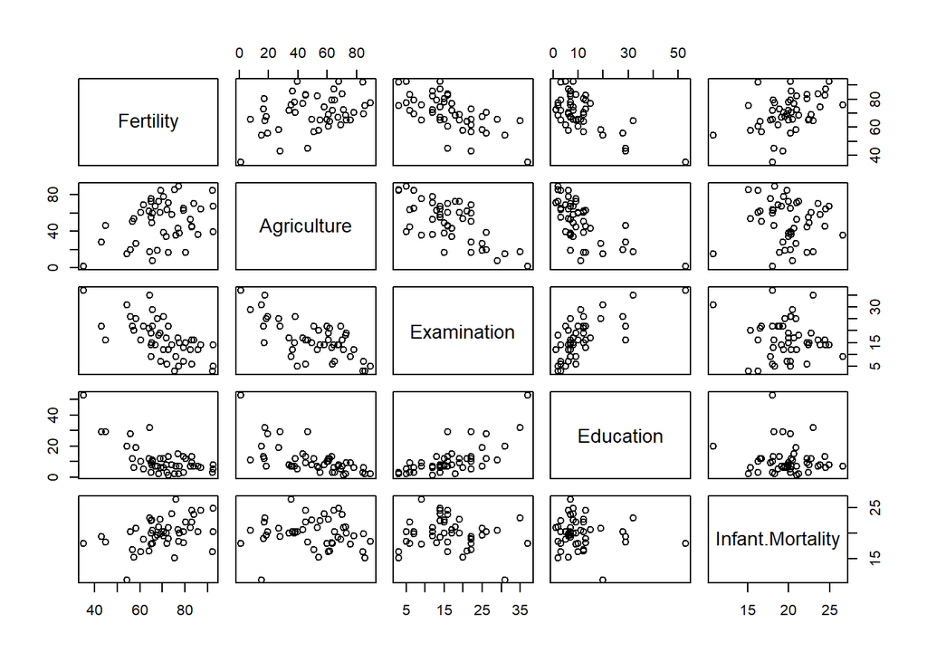

```r
pairs(data, col=iris[,3])
```

# 3. Melihat informasi lebih banyak mengenai mean, median, max

```r
summary(data)
```

```
##    Fertility      Agriculture     Examination      Education
##  Min.   :35.00   Min.   : 1.20   Min.   : 3.00   Min.   : 1.00
##  1st Qu.:64.70   1st Qu.:35.90   1st Qu.:12.00   1st Qu.: 6.00
##  Median :70.40   Median :54.10   Median :16.00   Median : 8.00
##  Mean   :70.14   Mean   :50.66   Mean   :16.49   Mean   :10.98
##  3rd Qu.:78.45   3rd Qu.:67.65   3rd Qu.:22.00   3rd Qu.:12.00
##  Max.   :92.50   Max.   :89.70   Max.   :37.00   Max.   :53.00
##  Infant.Mortality
##  Min.   :10.80
##  1st Qu.:18.15
##  Median :20.00
##  Mean   :19.94
##  3rd Qu.:21.70
##  Max.   :26.60
```

## 3.1 Melihat korelasi antar atribut

```r
cor(data)
```

```
##                   Fertility Agriculture Examination   Education
## Fertility         1.0000000  0.35307918  -0.6458827 -0.66378886
## Agriculture       0.3530792  1.00000000  -0.6865422 -0.63952252
## Examination      -0.6458827 -0.68654221   1.0000000  0.69841530
## Education        -0.6637889 -0.63952252   0.6984153  1.00000000
## Infant.Mortality  0.4165560 -0.06085861  -0.1140216 -0.09932185
##                  Infant.Mortality
## Fertility              0.41655603
## Agriculture           -0.06085861
## Examination           -0.11402160
## Education             -0.09932185
## Infant.Mortality       1.00000000
```

# 4. Melakukan Clustering FCM

## 4.1 Memanggil data clustering FCM

Memanggil data FCM

```r
res.fcm=fcm(data, centers = 2)
```

data diatas belum muncul karena datanya belum dipanggil

```r
v0 <- matrix(nrow=3, ncol=4,
     c(5.0, 3.4, 1.4, 0.3,
       6.7, 3.0, 5.6, 2.1,
       5.8, 2.7, 4.3, 1.4),
       byrow=TRUE)
print(v0)
```

```
##      [,1] [,2] [,3] [,4]
## [1,]  5.0  3.4  1.4  0.3
## [2,]  6.7  3.0  5.6  2.1
## [3,]  5.8  2.7  4.3  1.4
```

## 4.2 Melihat hasil clustering

Setelah memanggil data FCM, lalu dapat dilihat hasil clusteringnya sebagai berikut :

```r
summary(res.fcm)
```

```
## Summary for 'res.fcm'
##
## Number of data objects:  47
##
## Number of clusters:  2
##
## Crisp clustering vector:
##  [1] 2 1 1 2 2 2 1 1 1 1 1 1 1 1 1 1 2 2 2 1 1 1 1 1 1 1 1 1 2 1 1 1 1 1 1 1 1 1
## [39] 2 2 2 2 2 2 2 2 2
##
## Initial cluster prototypes:
##           Fertility Agriculture Examination Education Infant.Mortality
## Cluster 1      60.5        60.8          16        10             16.3
## Cluster 2      80.2        17.0          15        12             22.2
##
## Final cluster prototypes:
##           Fertility Agriculture Examination Education Infant.Mortality
## Cluster 1  72.85061    65.24837    13.33265  7.080801         19.96787
## Cluster 2  64.52186    25.56053    22.94476 17.706772         19.77866
##
## Distance between the final cluster prototypes
##           Cluster 1
## Cluster 2  1849.832
##
## Difference between the initial and final cluster prototypes
##           Fertility Agriculture Examination Education Infant.Mortality
## Cluster 1  12.35061    4.448371   -2.667350 -2.919199         3.667865
## Cluster 2 -15.67814    8.560532    7.944758  5.706772        -2.421344
##
## Root Mean Squared Deviations (RMSD): 17.63592
## Mean Absolute Deviation (MAD): 165.9123
##
## Membership degrees matrix (top and bottom 5 rows):
##              Cluster 1 Cluster 2
## Courtelary   0.1483978 0.8516022
## Delemont     0.6564526 0.3435474
## Franches-Mnt 0.5685773 0.4314227
## Moutier      0.4476138 0.5523862
## Neuveville   0.4780659 0.5219341
## ...
```

[output cut: 11 more lines]

```
##
## Dunn's Fuzziness Coefficients:
## dunn_coeff normalized
##  0.7572703  0.5145406
##
## Within cluster sum of squares by cluster:
##        1        2
## 9404.575 9646.732
## (between_SS / total_SS =  51.31%)
##
## Available components:
##  [1] "u"          "v"          "v0"         "d"          "x"
##  [6] "cluster"    "csize"      "sumsqrs"    "k"          "m"
## [11] "iter"       "best.start" "func.val"   "comp.time"  "inpargs"
## [16] "algorithm"  "call"
```

## 4.3 Melihat hasil cluster dalam bentuk scatter plot perpasangan

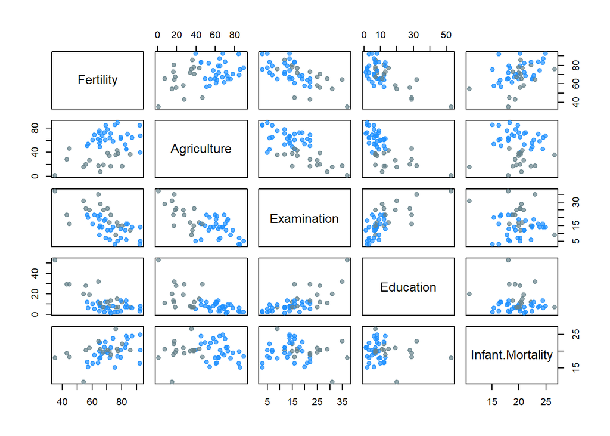

```r
plotcluster(res.fcm, cp=3, trans=TRUE)
```

-> keterangan diatas cp itu artinya calor atau tema warna -> angkat 3 itu merubah warnanya -> trans adalah tranparan atau warnanya transparan

## 4.4 Melihat hasil clustering dalam bentuk plot

Kita definisikan terlebih dahulu

```r
res.fcm2=ppclust2(res.fcm, "kmeans")
```

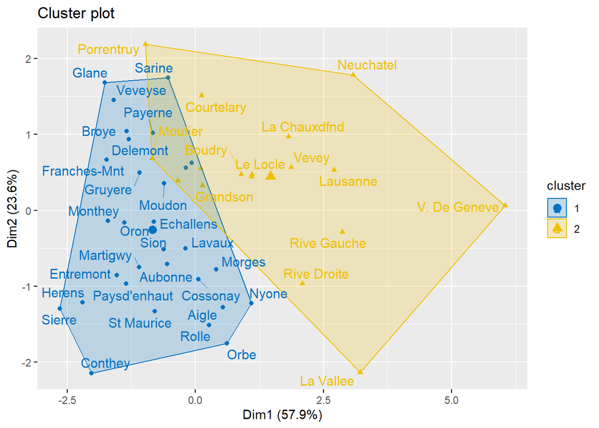

```r
res.fcm2 <- ppclust2(res.fcm, "kmeans")
factoextra::fviz_cluster(res.fcm2, data = data,
  ellipse.type = "convex",
  palette = "jco",
  repel = TRUE)
```